# Hoja de trabajo 4

Gustavo de León - 17085 | Andrés Urízar - 17632

19/03/2020

### Objetivo

Predecir los precios de las casa con un modelo lineal

#### Conjuntos de entrenamiento y prueba.

Se escogieron ciertas variables para hacer la particion. Todas variables cuantitativas. Sin embargo se haran pruebas con variables diferentes por eso se definen trainP 1,2 y 3 para mas adelante.

```r
  datos <- read.csv("train.csv", stringsAsFactors = FALSE)
  train <- datos[c("YearBuilt","YearRemodAdd","FullBath","TotRmsAbvGrd","GarageCars","SalePrice")]
  trainP1 <- datos[c("YearBuilt","YearRemodAdd","FullBath","TotRmsAbvGrd","SalePrice")]
  trainP2 <- datos[c("YearBuilt","FullBath","TotRmsAbvGrd","GarageCars","SalePrice")]
  trainP3 <- datos[c("YearBuilt","FullBath","TotRmsAbvGrd","SalePrice")]
  train[is.na(train)]<-0
```

Se hizo una partición aleatoria utilizando el 70% de los datos para entrenamiento y el 30% de los datos para prueba.

```r
  porcentaje<-0.7
  set.seed(200)
  corte <- sample(nrow(train),nrow(train)*porcentaje)
  train1<-train[corte,]
  test1<-train[-corte,]
```

```r
head(test1)
```

```
##    YearBuilt YearRemodAdd FullBath TotRmsAbvGrd GarageCars SalePrice
## 3       2001         2002        2            6          2    223500
## 9       1931         1950        2            8          2    129900
## 16      1929         2001        1            5          2    132000
## 19      2004         2004        1            6          2    159000
## 20      1958         1965        1            6          1    139000
## 22      1930         1950        1            6          1    139400
```

### Estimación del precio de las casas con todas las demas variables escogidas.

Se realizara el modelo lineal de todas las variables escogidas con el precio.

```r
fitMLM_Price<-lm(SalePrice~.,data = train)
```

El resumen del modelo:

```r
summary(fitMLM_Price)
```

```
##
## Call:
## lm(formula = SalePrice ~ ., data = train)
##
## Residuals:
##     Min      1Q  Median      3Q     Max
## -156769  -28049   -5558   19917  444762
##
## Coefficients:
##                Estimate Std. Error t value Pr(>|t|)
## (Intercept)  -2.281e+06  1.551e+05 -14.706  < 2e-16 ***
## YearBuilt     5.026e+02  6.247e+01   8.046 1.76e-15 ***
## YearRemodAdd  6.507e+02  8.157e+01   7.977 3.02e-15 ***
## FullBath      9.188e+03  3.373e+03   2.724  0.00653 **
## TotRmsAbvGrd  1.629e+04  1.033e+03  15.769  < 2e-16 ***
## GarageCars    3.358e+04  2.267e+03  14.813  < 2e-16 ***
## ---
## Signif. codes:  0 '***' 0.001 '**' 0.01 '*' 0.05 '.' 0.1 ' ' 1
##
## Residual standard error: 50230 on 1454 degrees of freedom
## Multiple R-squared:  0.6015, Adjusted R-squared:  0.6002
## F-statistic:   439 on 5 and 1454 DF,  p-value: < 2.2e-16
```

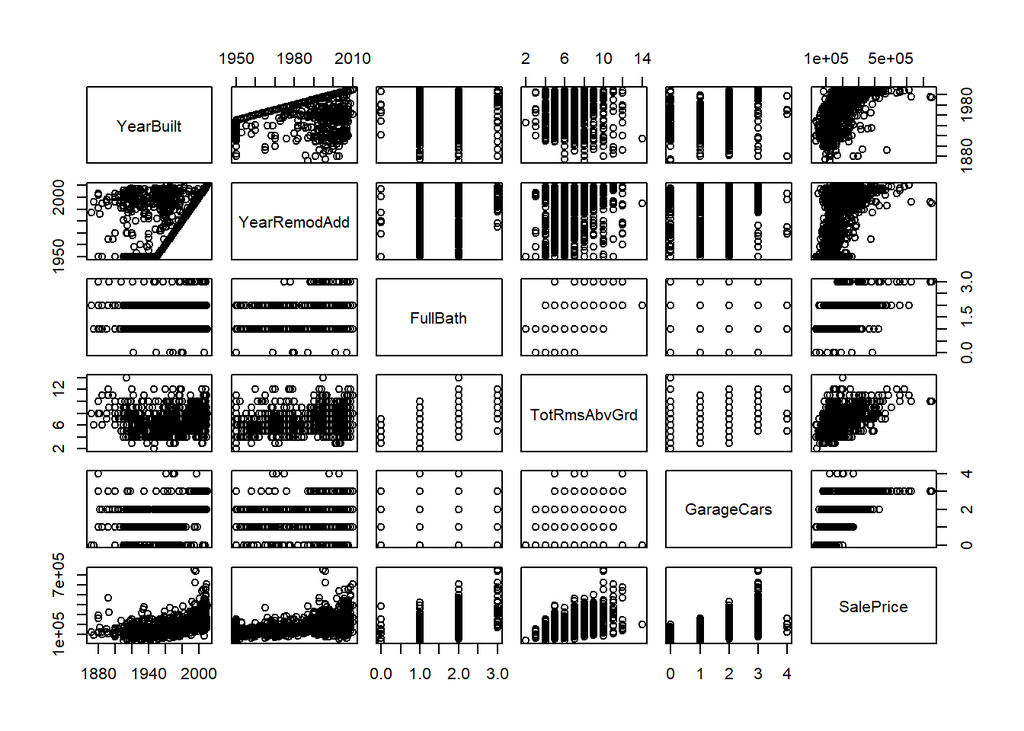

```r
plot(train)
```

Como se puede apreciar las variables escogidas presentan un problema de multicolinealidad especialmente la variable de GarageCars y YearRemodAdd

```r
# install.packages("corrplot")
library(corrplot)
matriz_cor <- cor(train)
matriz_cor
```

```
##               YearBuilt YearRemodAdd  FullBath TotRmsAbvGrd GarageCars
## YearBuilt    1.00000000    0.5928550 0.4682708   0.09558913  0.5378501
## YearRemodAdd 0.59285498    1.0000000 0.4390465   0.19173982  0.4206222
## FullBath     0.46827079    0.4390465 1.0000000   0.55478425  0.4696720
## TotRmsAbvGrd 0.09558913    0.1917398 0.5547843   1.00000000  0.3622886
## GarageCars   0.53785009    0.4206222 0.4696720   0.36228857  1.0000000
## SalePrice    0.52289733    0.5071010 0.5606638   0.53372316  0.6404092
##              SalePrice
## YearBuilt    0.5228973
## YearRemodAdd 0.5071010
## FullBath     0.5606638
## TotRmsAbvGrd 0.5337232
## GarageCars   0.6404092
## SalePrice    1.0000000
```

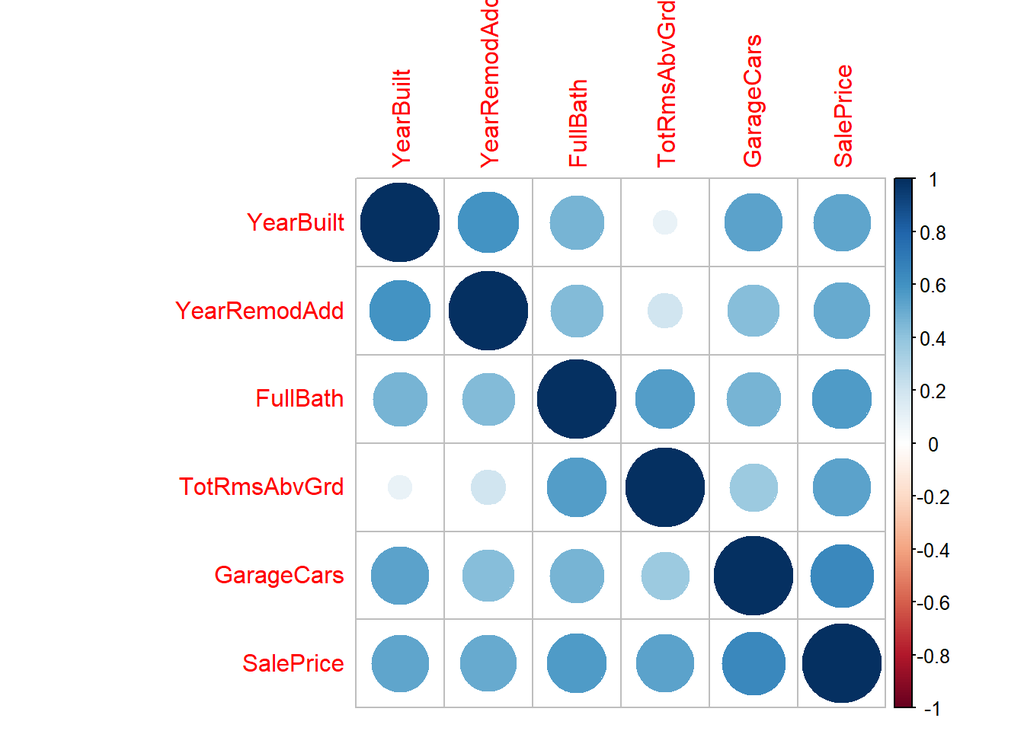

```r
corrplot(matriz_cor)
```

Probemos utilizar los datos de TrainP1 quitando la variable de GarageCar

```r
# install.packages("corrplot")
library(corrplot)
matriz_cor <- cor(trainP1)
matriz_cor
```

```
##               YearBuilt YearRemodAdd  FullBath TotRmsAbvGrd SalePrice
## YearBuilt    1.00000000    0.5928550 0.4682708   0.09558913 0.5228973
## YearRemodAdd 0.59285498    1.0000000 0.4390465   0.19173982 0.5071010
## FullBath     0.46827079    0.4390465 1.0000000   0.55478425 0.5606638
## TotRmsAbvGrd 0.09558913    0.1917398 0.5547843   1.00000000 0.5337232
## SalePrice    0.52289733    0.5071010 0.5606638   0.53372316 1.0000000
```

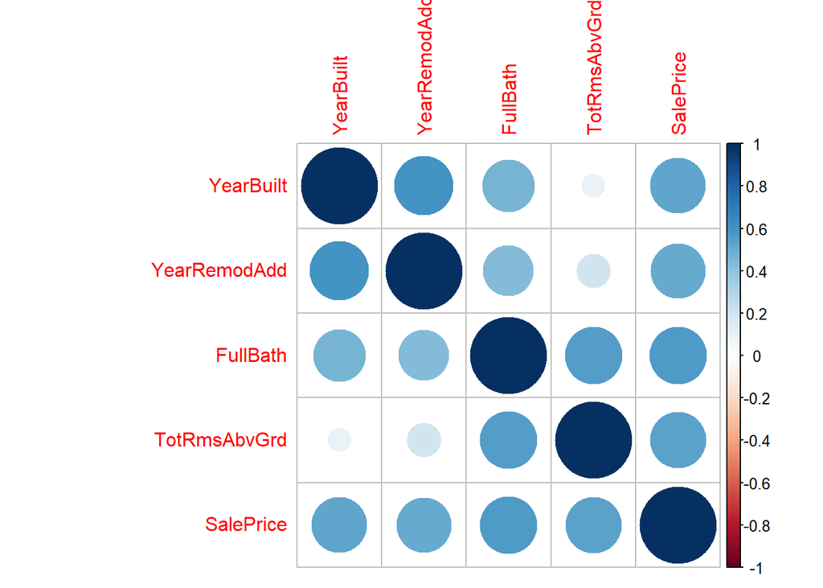

```r
corrplot(matriz_cor)
```

Probemos utilizar los datos de TrainP2 quitando la variable de YearRemodAdd

```r
# install.packages("corrplot")
library(corrplot)
matriz_cor <- cor(trainP2)
matriz_cor
```

```
##               YearBuilt  FullBath TotRmsAbvGrd GarageCars SalePrice
## YearBuilt    1.00000000 0.4682708   0.09558913  0.5378501 0.5228973
## FullBath     0.46827079 1.0000000   0.55478425  0.4696720 0.5606638
## TotRmsAbvGrd 0.09558913 0.5547843   1.00000000  0.3622886 0.5337232
## GarageCars   0.53785009 0.4696720   0.36228857  1.0000000 0.6404092
## SalePrice    0.52289733 0.5606638   0.53372316  0.6404092 1.0000000
```

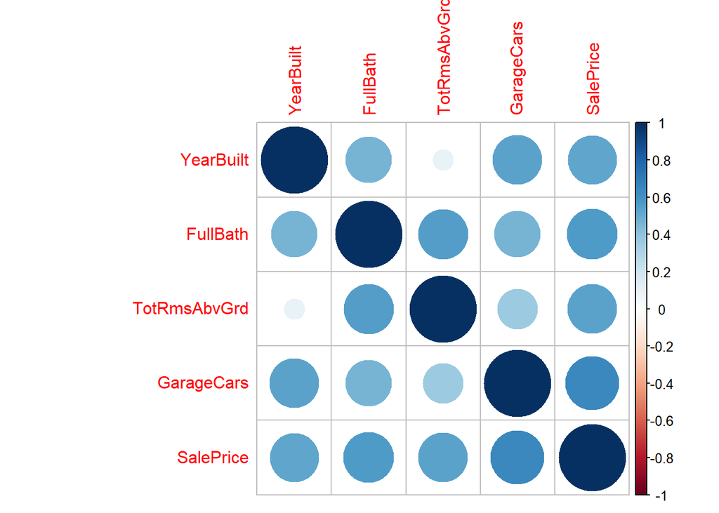

```r
corrplot(matriz_cor)
```

Probemos utilizar los datos de TrainP3 quitando las 2 variables GarageCar y YearRemodAdd

```r
# install.packages("corrplot")
library(corrplot)
matriz_cor <- cor(trainP3)
matriz_cor
```

```
##               YearBuilt  FullBath TotRmsAbvGrd SalePrice
## YearBuilt    1.00000000 0.4682708   0.09558913 0.5228973
## FullBath     0.46827079 1.0000000   0.55478425 0.5606638
## TotRmsAbvGrd 0.09558913 0.5547843   1.00000000 0.5337232
## SalePrice    0.52289733 0.5606638   0.53372316 1.0000000
```

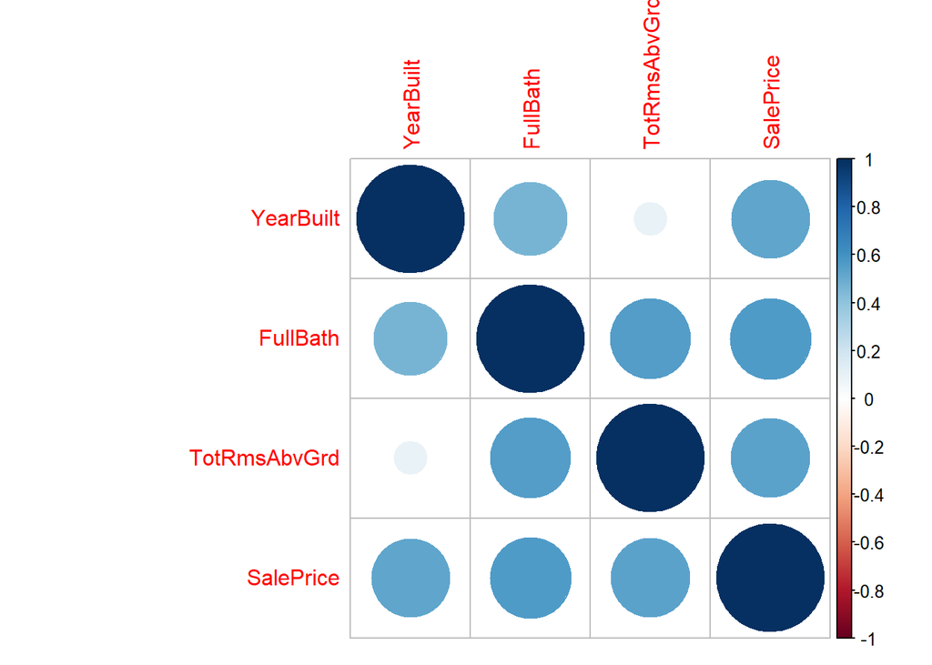

```r
corrplot(matriz_cor)
```

### Nuevo modelo

Ahora realicemos el modelo lineal con los datos de trainP3

```r
fitMLM_Price<-lm(SalePrice~.,data = trainP3)
```

Resumen del modelo

```r
summary(fitMLM_Price)
```

```
##
## Call:
## lm(formula = SalePrice ~ ., data = trainP3)
##
## Residuals:
##     Min      1Q  Median      3Q     Max
## -182828  -29843   -6573   18793  450362
##
## Coefficients:
##                Estimate Std. Error t value Pr(>|t|)
## (Intercept)  -2.172e+06  1.084e+05 -20.030  < 2e-16 ***
## YearBuilt     1.111e+03  5.555e+01  19.989  < 2e-16 ***
## FullBath      1.859e+04  3.644e+03   5.102  3.8e-07 ***
## TotRmsAbvGrd  2.062e+04  1.096e+03  18.806  < 2e-16 ***
## ---
## Signif. codes:  0 '***' 0.001 '**' 0.01 '*' 0.05 '.' 0.1 ' ' 1
##
## Residual standard error: 55200 on 1456 degrees of freedom
## Multiple R-squared:  0.5182, Adjusted R-squared:  0.5172
## F-statistic:   522 on 3 and 1456 DF,  p-value: < 2.2e-16
```

El R ajustado bajo asi que revisemos los residuos

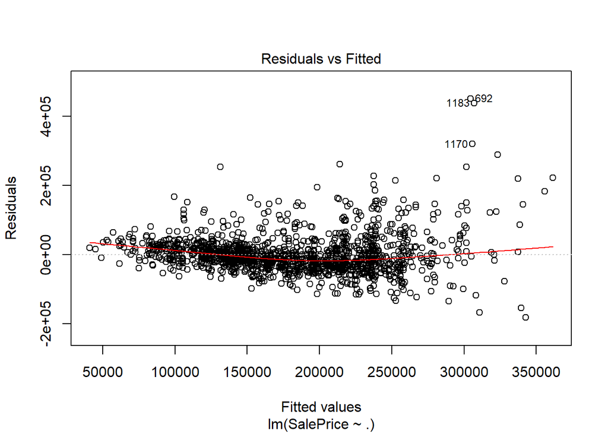

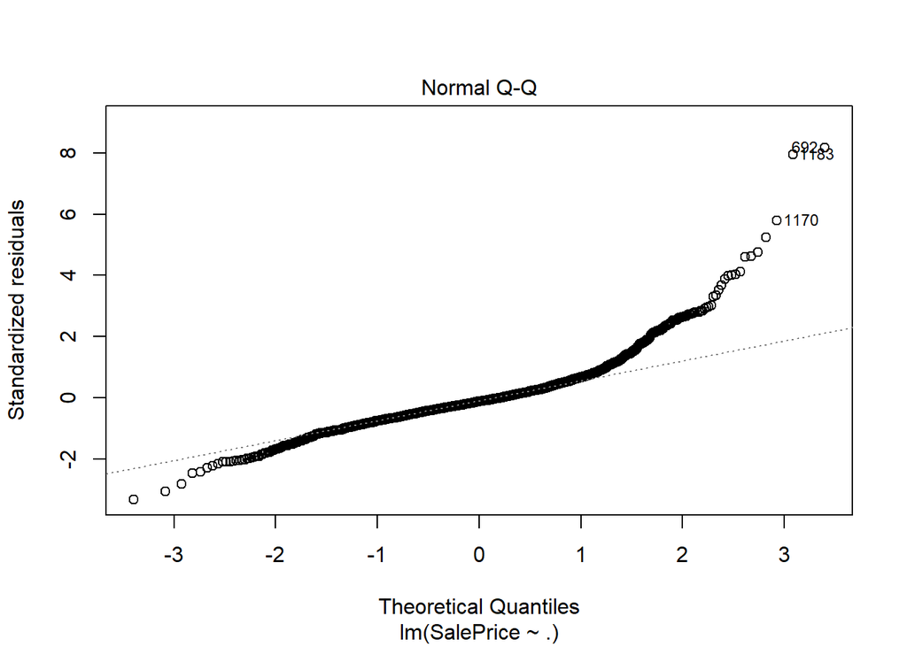

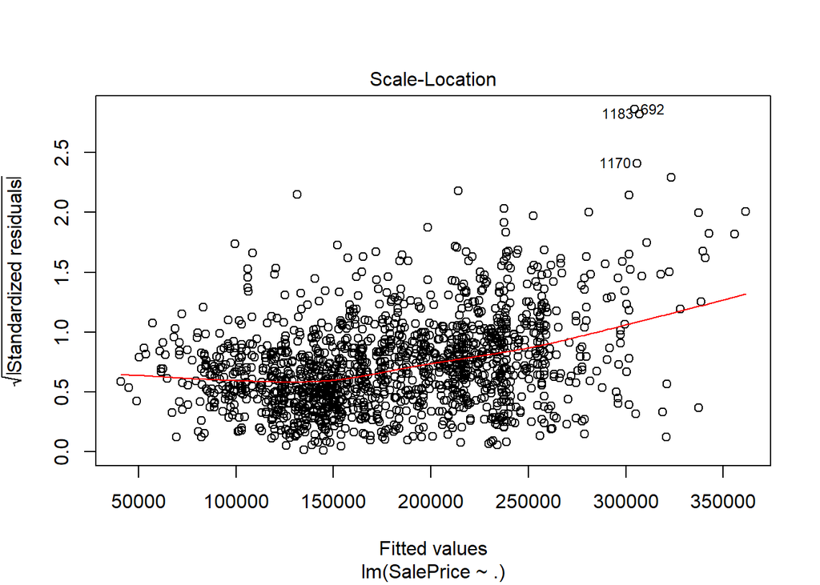

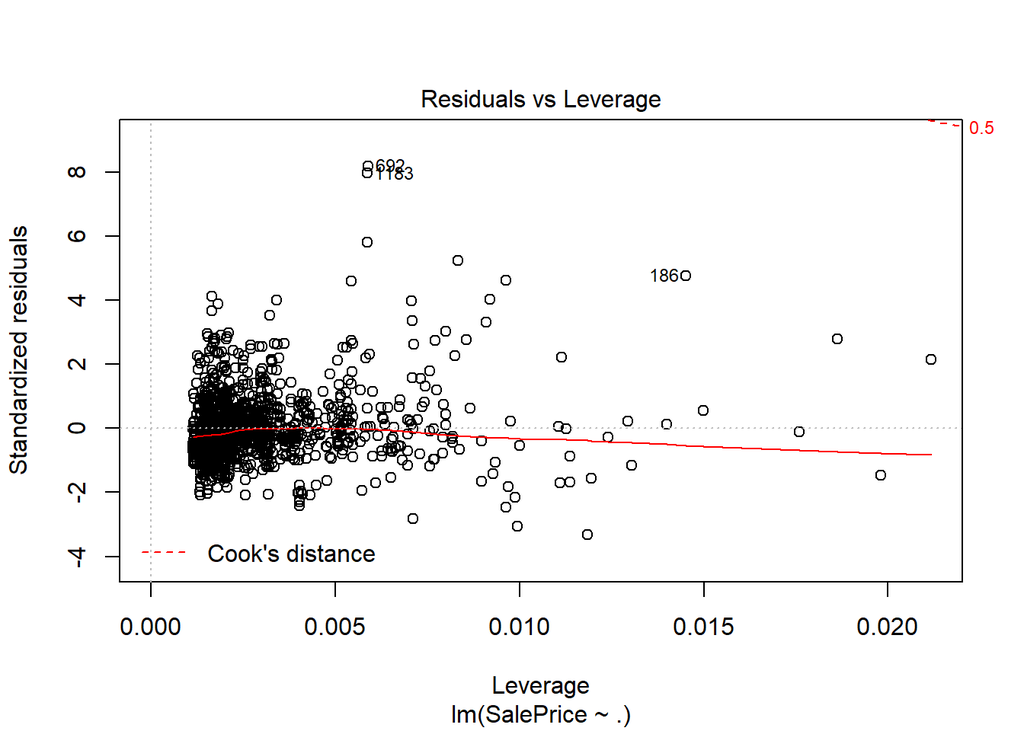

```r
plot(fitMLM_Price)
```

Los graficos se ven que los residuos si estan distriubidos aleatoriamente alrededor de 0 como en la grafica de Residuals vs Fitted. Aunque en el grafico q-q se nota que existen varios datos extremos que desbalancean los datos. Esto se vera mejor en un histograma.

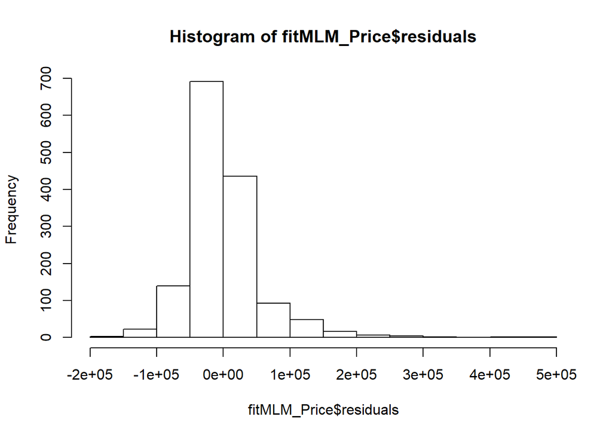

```r
hist(fitMLM_Price$residuals)
```

Se ve que los datos no son normales, una razon por la cual afecta al modelo.

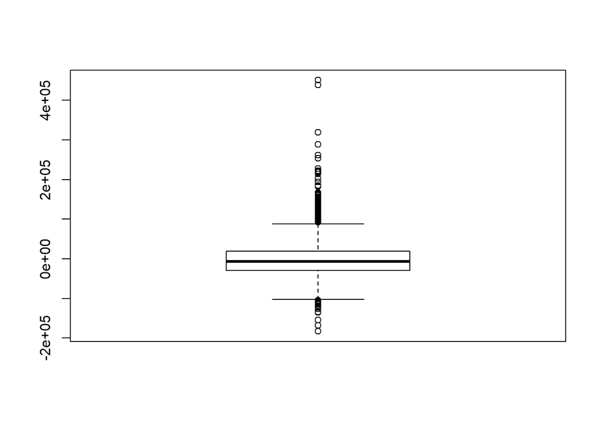

```r
boxplot(fitMLM_Price$residuals)
```

Igual en el diagrama de caja y bigotes se nota todas las variables que desbalancean el modelo.

La prueba de lilliefors da que se rechaza la hipotesis de normalidad para un valor de significación de 0.05. Asi que lo mas probable es que no prediga bien.

```r
library(nortest)
lillie.test(fitMLM_Price$residuals)
```

```
##
##  Lilliefors (Kolmogorov-Smirnov) normality test
##
## data:  fitMLM_Price$residuals
## D = 0.11972, p-value < 2.2e-16
```

```r
predMLM<-predict(fitMLM_Price,newdata = test1[,c(1,3,4)])
library(caret)
RMSE(predMLM,test1$SalePrice)
```

```
## [1] 61381.91
```

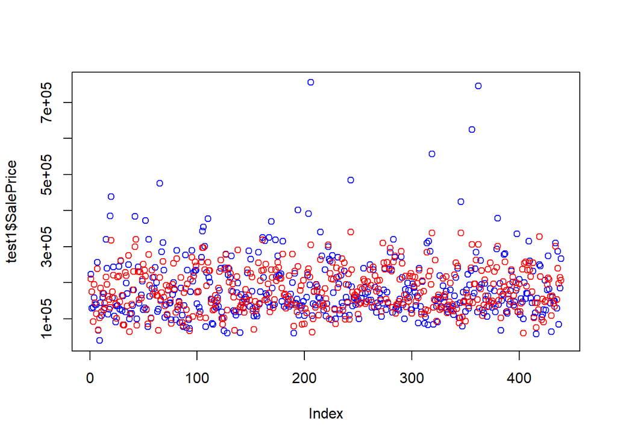

```r
plot(test1$SalePrice,col="blue")
points(predMLM, col="red")
```

Debido a la gran cantidad de puntos no se puede comparar 1 por 1 pero podemos notar que la gran maypria de puntos azules si estan como que acomparañados de un punto rojo, o sea las predicciones si tienen lógica con el dato real sin embargo en los puntos atipicos si no se acercaron.

```r
summary(test1$SalePrice-predMLM)
```

```
##    Min. 1st Qu.  Median    Mean 3rd Qu.    Max.
## -167671  -29538   -4953    2338   18868  450362
```